# Using the QuakeCoursera Package

Jake Markman

7/11/2017

QuakeCoursera is a package developed as the capstone project for the Advanced R Programming specialization on [Coursera](http://www.coursera.org). It exists to help clean and visualize data from the [NOAA Significant Earthquake Database](https://www.ngdc.noaa.gov/nndc/struts/form?t=101650&s=1&d=1)

This document serves as an introduction to the package and demonstrates how to use each of the individual features.

This document is organized into three broad categores, as follows:

1. Getting and Cleaning the Data
2. Timeline Visualization
3. Interactive Mapping

## Getting and Cleaning the Data

The [NOAA Significant Earthquake Database](https://www.ngdc.noaa.gov/nndc/struts/form?t=101650&s=1&d=1) is an amazing resource. It has information on earthquakes that have occurred worldwide over more than 4000 years. However as a raw text file, it isn’t the easist to work with.

Some cleaning is required to get the data ready to work nicely with the visualization functions provided below. The easist thing to do is simply to load the clean dataset included with this package using the `data()` function:

```r
data('clean_NOAA')
```

The drawback with this approach is that the included dataset has been frozen as of the date of the download for creation of this package, July 1 2017. You can download the most recent dataset yourself [here](https://www.ngdc.noaa.gov/nndc/struts/results?type_0=Exact&query_0=$ID&t=101650&s=13&d=189&dfn=signif.txt) and clean it using the `eq_clean_data()` function. Assuming you have downloaded the raw data to your working directory as ‘signif.txt’:

```r
clean_NOAA <- readr::read_delim('signif.txt',delim = '\t') %>%
    eq_clean_data()
```

Eather way, `clean_NOAA` is now ready to be used for visualizing the historical earthquake data.

### Unexported Helper Functions

To minimize cluttering the namespace of the user, only the most likely to be used functions are exported and easily available. However, several helper functions are included which can be accessed directly using the `:::` operator.

`eq_good_date()` Takes year, month, and day as integer input and returns a valid date object. Negative years are interpreted as BCE dates.

```r
QuakeCoursera:::eq_good_date(2017, 7, 11)
```

```
#> [1] "2017-07-11"
```

```r
QuakeCoursera:::eq_good_date(-2000, 1, 1)
```

```
#> [1] "-2000-01-01"
```

It should be noted that R date objects do not handle BCE dates very well, and date differences between BCE and CE will be off by a year, as R date objects behave as if a year 0 exists, when in fact 1 CE began immediately after 1 BCE concluded.

`eq_location_clean()` Takes a string input, strips out everything before a ‘:’ character, converts the remainder to Title Case, and cleans up comma formats. This is useful as the LOCATION_NAME field in the raw data duplicates the data in COUNTRY (always before a colon) and makes the rest attractive for use as a label.

```r
QuakeCoursera:::eq_location_clean("USA:  sAn francisco")
```

```
#> [1] "San Francisco"
```

`title_case()` Converts any string to title case. What is title case? ‘This Is Title Case’. ‘this is not title case’.

```r
QuakeCoursera:::title_case('this is now title case')
```

```
#> [1] "This Is Now Title Case"
```

```r
QuakeCoursera:::title_case('THIS IS NOW TITLE CASE TOO')
```

```
#> [1] "This Is Now Title Case Too"
```

## Timeline Visualization

A timeline is a great way to see when significant earthquakes have ocurred. This package includes a custom `geom` and `stat` to make creating just such a plot easier with the widely-used `ggplot2` package.

`geom_timeline()` takes, at minimum, a series of dates as its `x` aesthetic, and plots those dates as a series of circles. It defaults to using `stat_timeline()` for data transfomation, which allows `x_min` and `x_max` arguments to be passed to limit the date range to be plotted. In its simplest form:

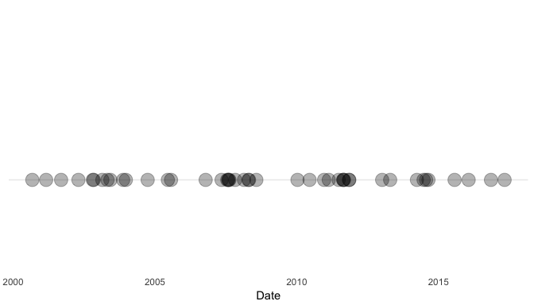

```r
filter(clean_NOAA, COUNTRY == "USA") %>% ggplot(aes(x = DATE)) +
    geom_timeline(x_min = ymd("2000-01-01"), x_max = ymd("2017-07-01")) +
    theme_minimal() + theme(panel.grid.major.x = element_blank()) +
    theme(axis.text.y  = element_blank()) +
    theme(panel.grid.minor.x = element_blank()) +
    scale_y_continuous(breaks = 1, limits = c(0.5, 2)) +
    labs(x = "Date")
```

Adding in optional `y` and `size` aesthetics make the visualization even more powerful–we can compare the magnatude of earthquakes among countries during the same period, for exxample:

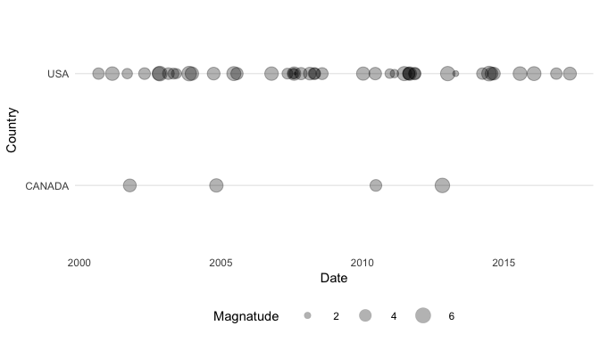

```r
filter(clean_NOAA, COUNTRY == "USA" | COUNTRY == "CANADA") %>%
    ggplot(aes(x = DATE, y = COUNTRY, size = EQ_PRIMARY)) +
    geom_timeline(x_min = ymd("2000-01-01"), x_max = ymd("2017-07-01")) +
    theme_minimal() + theme(panel.grid.major.x = element_blank()) +
    theme(panel.grid.minor.x = element_blank()) + theme(legend.position = "bottom") +
    theme(legend.key.size = unit(0.078, 'npc')) +
    labs(x = "Date", y = "Country", size = "Magnatude")
```

This package also has a Geom and Stat pair to allow easy labeling of the occurrences plotted on the timeline–`geom_timeline_label()` and `stat_timeline_label()`. Once again the Stat is called by default within the geom, so there is no need to demonstrate the Stat. The Geom requires a `label` aesthetic, the text for the labels to be added. It also adds an additional optional `magnatidue` aesthetic which, when combined with the optional `top_x_mag` argument limits the total labels shown by order of `magnatude`. So, extending the above:

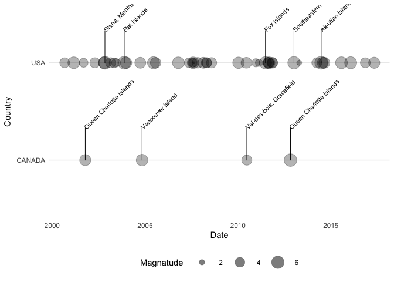

```r
xmin <- ymd("2000-01-01")
xmax <- ymd("2017-07-01")
filter(clean_NOAA, COUNTRY == "CANADA" | COUNTRY == "USA") %>%
    ggplot(aes(x = DATE, y = COUNTRY, size = EQ_PRIMARY)) +
    geom_timeline(x_min = xmin, x_max = xmax) +
    geom_timeline_label(aes(label = LOCATION_NAME, magnatude = EQ_PRIMARY),
                        x_min = xmin, x_max = xmax, top_x_mag = 5) +
    theme_minimal() + theme(panel.grid.major.x = element_blank()) +
    theme(panel.grid.minor.x = element_blank()) + theme(legend.position = "bottom") +
    theme(legend.key.size = unit(0.078, 'npc')) +
    labs(x = "Date", y = "Country", size = "Magnatude")
```

## Interactive Mapping

The final component to this package is an easy shortcut for creating an interactive map of earthquake locations using the popular `leaflet` package. The function for doing so is `eq_map()`, which by default plots the events by `LATITUDE` or `LONGITUDE` found in the `data` argument as circles, with the magnatude of the earthquake as found in `EQ_PRIMARY` as the size of the circles. An optional `annot_col` argument allows labeling the locations (the label comes up when the circle is clicked). For example:

```r
mp <- clean_NOAA %>% filter(year(DATE) >= 2000 & COUNTRY == "MEXICO") %>%
    eq_map(annot_col = "DATE")

mp
```

[interactive chart not shown]

Since no single column in the data is an ideal label, the function `eq_create_label()` combines the data in `LOCATION_NAME`, `EQ_PRIMARY`, and `TOTAL_DEATHS` into a single column, as well as adding html formatting for a nice display. Once again, click the circles to see the labels:

```r
mp <- clean_NOAA %>% filter(year(DATE) >= 2000 & COUNTRY == "MEXICO") %>%
    mutate(popup_text = eq_create_label(.)) %>%
    eq_map(annot_col = "popup_text")

mp
```

[interactive chart not shown]